# Identifikasi Data Stasioner atau Tidak Stasioner

Muhammad Abshor Dzulhij Rizki

2024-09-23

```r
library(ggplot2)
library(tsibble)
library(tseries)
library(MASS)
```

### Impor Data*

```r
library(readxl)
data<- read_excel("C:\\Users\\Jidan statistik\\Downloads\\Data Hujan Bogor 2023-Now.xlsx")

#memasukan data hanya baris 363 hingga 483 aja
data1<-data[363:483,]
```

```r
head(data1)
```

| Tanggal | Akumulasi Hujan |
| --- | --- |
| 29-Dec | 67.4033 |
| 30-Dec | 48.2979 |
| 31-Dec | 187.0357 |
| 1-Jan | 65.9340 |
| 2-Jan | 116.2440 |
| 3-Jan | 140.2729 |

```r
str(data1)
```

```
## tibble [121 × 2] (S3: tbl_df/tbl/data.frame)
##  $ Tanggal        : chr [1:121] "29-Dec" "30-Dec" "31-Dec" "1-Jan" ...
##  $ Akumulasi Hujan: num [1:121] 67.4 48.3 187 65.9 116.2 ...
```

### Eksplorasi Data*

```r
data1.ts<-ts(data1$`Akumulasi Hujan`)
summary(data1.ts)
```

```
##     Min.  1st Qu.   Median     Mean  3rd Qu.     Max.
##   0.0001  10.4479  36.2017  57.8091  95.7683 341.5969
```

### Plot *Time Series*

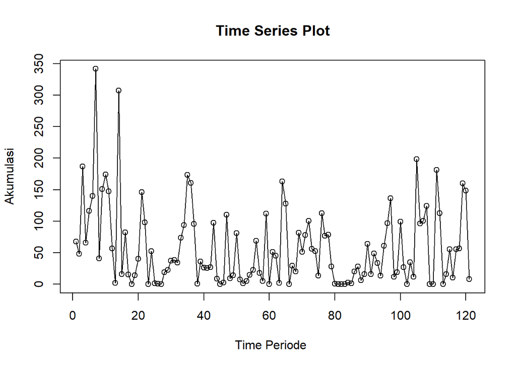

```r
ts.plot(data1.ts, xlab="Time Periode ", ylab="Akumulasi",
        main = "Time Series Plot")
points(data1.ts)
```

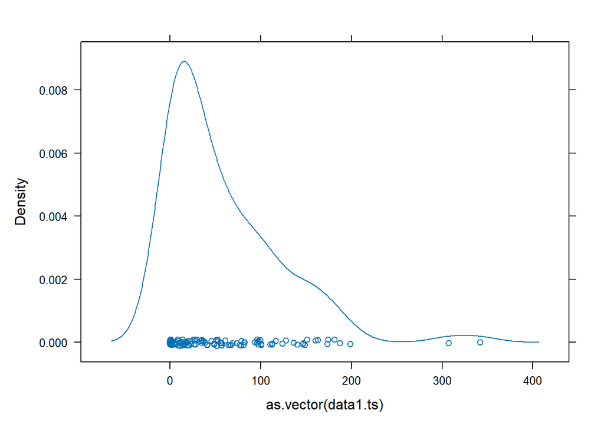

```r
lattice :: densityplot(as.vector (data1.ts))
```

```r
mean(density(data1.ts)$x)
```

```
## [1] 170.7985
```

### Plot ACF

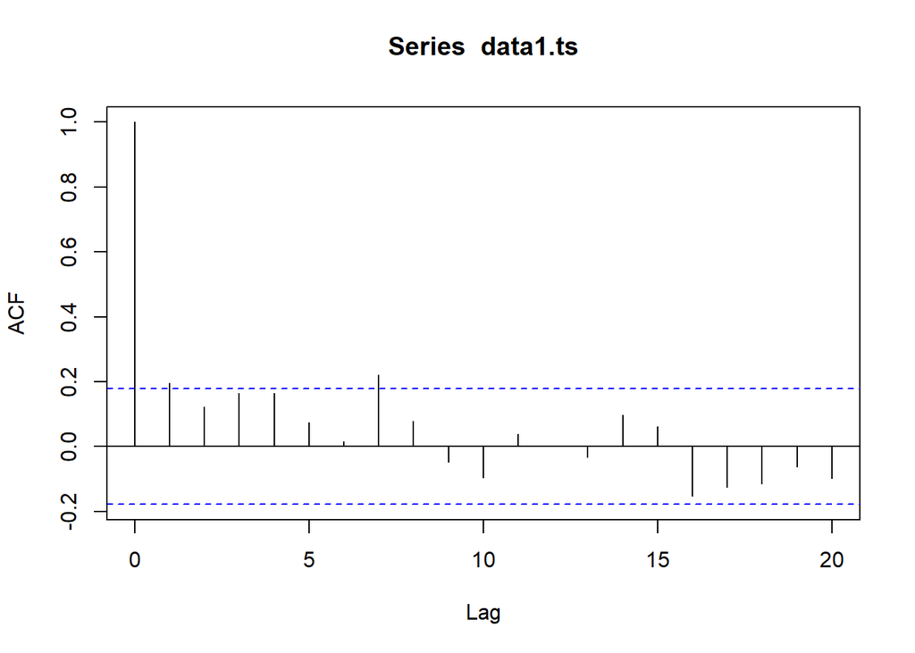

```r
acf(data1.ts)
```

Berdasarkan plot ACF, terlihat bahwa plot ACF pada data tersebut cenderung *tails off* dan membentuk gelombang sinus.

### Uji ADF

```r
tseries::adf.test(data1.ts)
```

```
##
##  Augmented Dickey-Fuller Test
##
## data:  data1.ts
## Dickey-Fuller = -3.5739, Lag order = 4, p-value = 0.03859
## alternative hypothesis: stationary
```

$H_0$ : Data tidak stasioner dalam rataan

$H_1$ : Data stasioner dalam rataan

Berdasarkan uji ADF tersebut, didapat *p-value* sebesar 0.03859 yang lebih kecil dari taraf nyata 5% sehingga tolak $H_0$ dan menandakan bahwa data stasioner dalam rataan. Hal ini sesuai dengan hasil eksplorasi menggunakan plot time series dan plot ACF.

### Plot Box-Cox

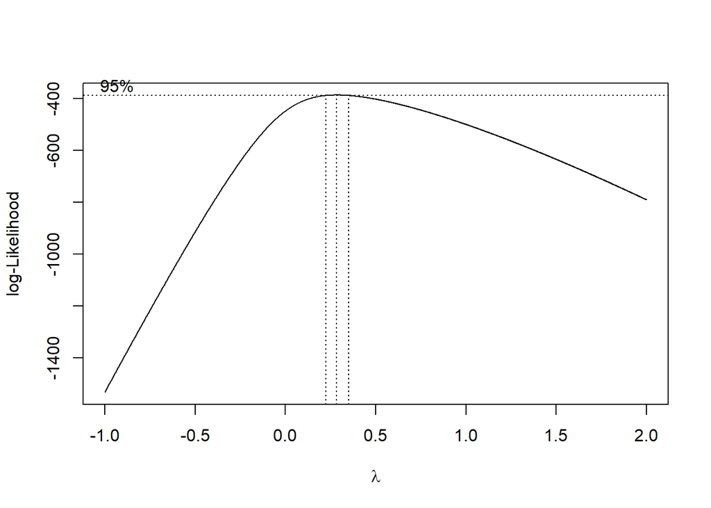

```r
indeks <- seq(1:121)
bc = boxcox(data1.ts~indeks, lambda = seq (-1, 2, by = 0.001))
```

```r
lambda<- bc$x[which.max(bc$y)]
lambda
```

```
## [1] 0.284
```

```r
bc$x[bc$y > max(bc$y) - 1/2 * qchisq(.95,1)]
```

```
##   [1] 0.224 0.225 0.226 0.227 0.228 0.229 0.230 0.231 0.232 0.233 0.234 0.235
##  [13] 0.236 0.237 0.238 0.239 0.240 0.241 0.242 0.243 0.244 0.245 0.246 0.247
##  [25] 0.248 0.249 0.250 0.251 0.252 0.253 0.254 0.255 0.256 0.257 0.258 0.259
##  [37] 0.260 0.261 0.262 0.263 0.264 0.265 0.266 0.267 0.268 0.269 0.270 0.271
##  [49] 0.272 0.273 0.274 0.275 0.276 0.277 0.278 0.279 0.280 0.281 0.282 0.283
##  [61] 0.284 0.285 0.286 0.287 0.288 0.289 0.290 0.291 0.292 0.293 0.294 0.295
##  [73] 0.296 0.297 0.298 0.299 0.300 0.301 0.302 0.303 0.304 0.305 0.306 0.307
##  [85] 0.308 0.309 0.310 0.311 0.312 0.313 0.314 0.315 0.316 0.317 0.318 0.319
##  [97] 0.320 0.321 0.322 0.323 0.324 0.325 0.326 0.327 0.328 0.329 0.330 0.331
## [109] 0.332 0.333 0.334 0.335 0.336 0.337 0.338 0.339 0.340 0.341 0.342 0.343
## [121] 0.344 0.345 0.346 0.347 0.348 0.349 0.350 0.351
```

Gambar di atas menunjukkan nilai *rounded value* ($\lambda$) optimum sebesar **0.284** dan pada selang kepercayaan 95% nilai memiliki batas bawah **0.224** dan batas atas **0.351**. Selang tersebut tidak memuat nilai satu sehingga dapat dikatakan bahwa data curah hujan bogor tidak stasioner dalam ragam.

### SUMMARY Data Keseluruhan

pada data keseluruhan $121$ periode dapat di identifikasi stasionernya dengan melakukan uji ACF dengan hasil Tail off lalu dilakukan uji stasioner bagi rataan Menggunakan uji ADF.hasil p-value $0.03859$ yang lebih kecil dari taraf nyata 5% sehingga tolak $H_0$ dan menandakan bahwa data stasioner dalam rataan. lalu dilakukan uji stasioner bagi ragam Menggunakan Box-Cox dengan hasil lambda $0.284$ dan pada selang kepercayaan 95% nilai memiliki batas bawah $0.224$ dan batas atas $0.351$.

Dari seluruh uji dapat di identifikasi bahwa data keseluruhan 121 periode termasuk dalam model yang stasioner pada rata-ratanya akan tetapi tidak stasioner terhadap ragamnya

### Partisi Data (Data Training dan Data Testing) dibagi data training 1-50 data uji 51-100

#### Bagian 1 (Data Training)

```r
data_training <- data1[1:50,]
data_training.ts <- ts(data_training$`Akumulasi Hujan`)

mean(data_training.ts)
```

```
## [1] 70.00207
```

```r
var(data_training.ts)
```

```
## [1] 5792.798
```

#### Plot Time Series

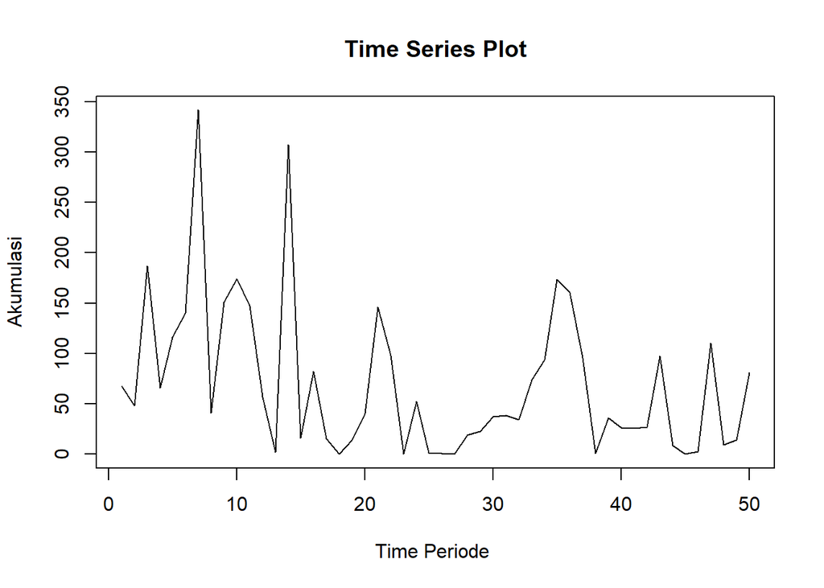

```r
ts.plot(data_training.ts, xlab="Time Periode ", ylab="Akumulasi",
        main = "Time Series Plot")
```

#### Plot ACF

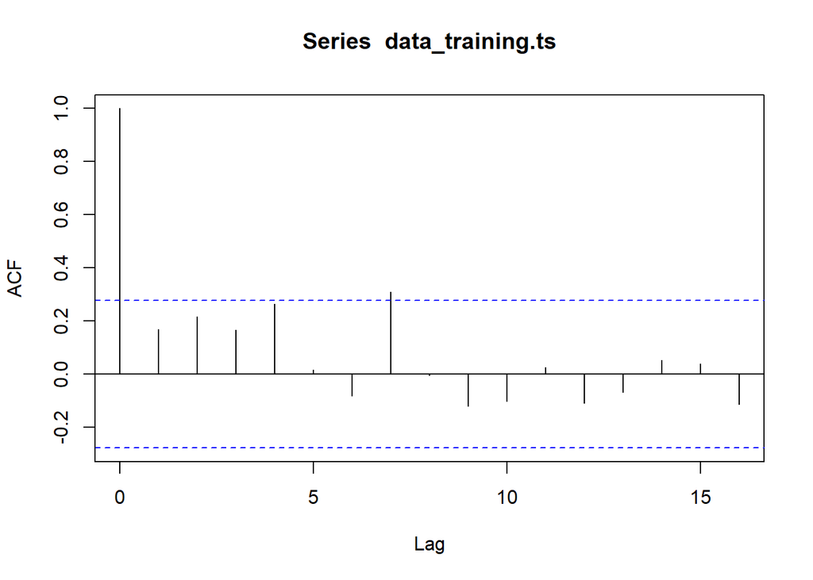

```r
acf(data_training.ts)
```

Berdasarkan plot ACF, terlihat bahwa plot ACF pada data tersebut cenderung *tails off* dan membentuk gelombang sinus.

#### Uji ADF

```r
tseries::adf.test(data_training.ts)
```

```
##
##  Augmented Dickey-Fuller Test
##
## data:  data_training.ts
## Dickey-Fuller = -2.4803, Lag order = 3, p-value = 0.3816
## alternative hypothesis: stationary
```

$H_0$ : Data tidak stasioner dalam rataan

$H_1$ : Data stasioner dalam rataan

Berdasarkan uji ADF tersebut, didapat *p-value* sebesar 0.3816 yang lebih besar dari taraf nyata 5% sehingga tak tolak $H_0$ dan menandakan bahwa data tidak stasioner dalam rataan.

#### Plot Boxcox

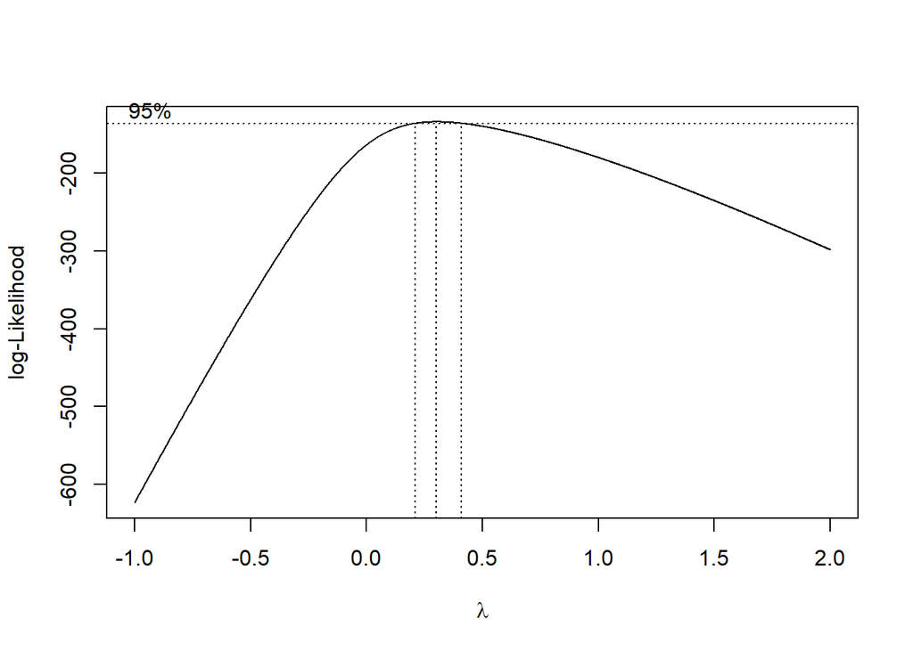

```r
index_2 <- seq(1:50)
bc = boxcox(data_training.ts~index_2, lambda = seq(-1,2,by=0.001))
```

```r
#Nilai Rounded Lambda
lambda <- bc$x[which.max(bc$y)]
lambda
```

```
## [1] 0.302
```

```r
#SK
bc$x[bc$y > max(bc$y) - 1/2 * qchisq(.95,1)]
```

```
##   [1] 0.212 0.213 0.214 0.215 0.216 0.217 0.218 0.219 0.220 0.221 0.222 0.223
##  [13] 0.224 0.225 0.226 0.227 0.228 0.229 0.230 0.231 0.232 0.233 0.234 0.235
##  [25] 0.236 0.237 0.238 0.239 0.240 0.241 0.242 0.243 0.244 0.245 0.246 0.247
##  [37] 0.248 0.249 0.250 0.251 0.252 0.253 0.254 0.255 0.256 0.257 0.258 0.259
##  [49] 0.260 0.261 0.262 0.263 0.264 0.265 0.266 0.267 0.268 0.269 0.270 0.271
##  [61] 0.272 0.273 0.274 0.275 0.276 0.277 0.278 0.279 0.280 0.281 0.282 0.283
##  [73] 0.284 0.285 0.286 0.287 0.288 0.289 0.290 0.291 0.292 0.293 0.294 0.295
##  [85] 0.296 0.297 0.298 0.299 0.300 0.301 0.302 0.303 0.304 0.305 0.306 0.307
##  [97] 0.308 0.309 0.310 0.311 0.312 0.313 0.314 0.315 0.316 0.317 0.318 0.319
## [109] 0.320 0.321 0.322 0.323 0.324 0.325 0.326 0.327 0.328 0.329 0.330 0.331
## [121] 0.332 0.333 0.334 0.335 0.336 0.337 0.338 0.339 0.340 0.341 0.342 0.343
## [133] 0.344 0.345 0.346 0.347 0.348 0.349 0.350 0.351 0.352 0.353 0.354 0.355
## [145] 0.356 0.357 0.358 0.359 0.360 0.361 0.362 0.363 0.364 0.365 0.366 0.367
## [157] 0.368 0.369 0.370 0.371 0.372 0.373 0.374 0.375 0.376 0.377 0.378 0.379
## [169] 0.380 0.381 0.382 0.383 0.384 0.385 0.386 0.387 0.388 0.389 0.390 0.391
## [181] 0.392 0.393 0.394 0.395 0.396 0.397 0.398 0.399 0.400 0.401 0.402 0.403
## [193] 0.404 0.405 0.406 0.407 0.408
```

Gambar di atas menunjukkan nilai *rounded value* ($\lambda$) optimum sebesar **0.302** dan pada selang kepercayaan 95% nilai memiliki batas bawah **0.212** dan batas atas **0.408**. Selang tersebut tidak memuat nilai satu sehingga dapat dikatakan bahwa data curah hujan bogor tidak stasioner dalam ragam.

### SUMMARY Data Training

Dari seluruh uji dapat di identifikasi bahwa data training 50 periode termasuk dalam model yang stasioner (dilihat dari ACF) akan tetapi tidak stasioner terhadap rataannya dan tidak stasioner pada ragam

#### Bagian 2 (Data Uji)

```r
data_uji <- data1[51:100,]
data_uji.ts <- ts(data_uji$`Akumulasi Hujan`)

mean(data_uji.ts)
```

```
## [1] 41.94017
```

```r
var(data_uji.ts)
```

```
## [1] 1791.986
```

#### Plot Time Series

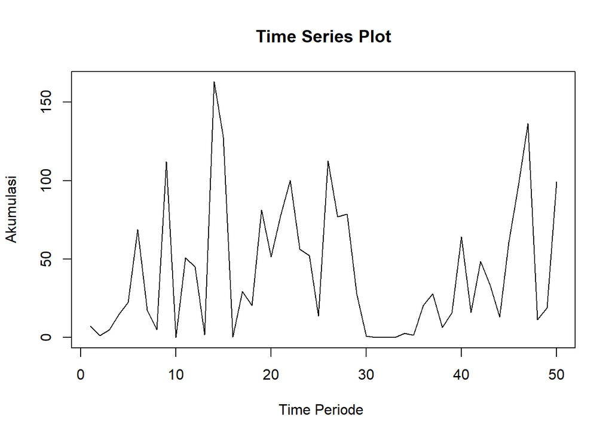

```r
ts.plot(data_uji.ts, xlab="Time Periode ", ylab="Akumulasi",
        main = "Time Series Plot")
```

#### Plot ACF

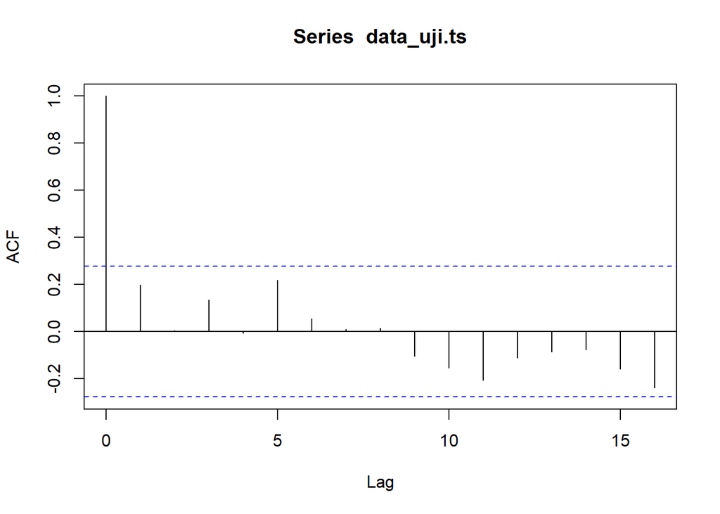

```r
acf(data_uji.ts)
```

Berdasarkan plot ACF, terlihat bahwa plot ACF pada data tersebut cenderung *cut off* akan tetapi tidak ada lag yang mempengaruhi data tersebut.

#### Uji ADF

```r
adf.test(data_uji.ts)
```

```
##
##  Augmented Dickey-Fuller Test
##
## data:  data_uji.ts
## Dickey-Fuller = -3.0454, Lag order = 3, p-value = 0.155
## alternative hypothesis: stationary
```

$H_0$ : Data tidak stasioner dalam rataan

$H_1$ : Data stasioner dalam rataan

Berdasarkan uji ADF tersebut, didapat *p-value* sebesar 0.155 yang lebih besar dari taraf nyata 5% sehingga tidak tolak $H_0$ dan menandakan bahwa data tidak stasioner dalam rataan. Hal ini sesuai dengan hasil eksplorasi menggunakan plot time series dan plot ACF.

#### Plot Boxcox

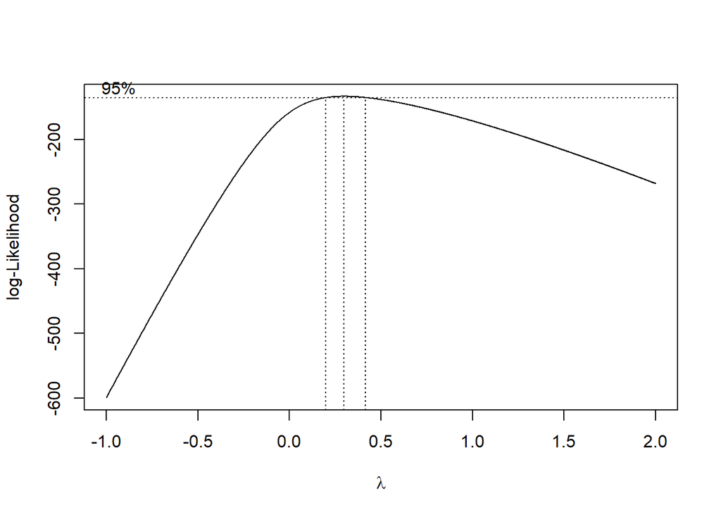

```r
index3 <- seq(51:100)
bc = boxcox(data_uji.ts~index3, lambda = seq(-1,2,by=0.001))
```

```r
#Nilai Rounded Lambda
lambda <- bc$x[which.max(bc$y)]
lambda
```

```
## [1] 0.298
```

```r
#SK
bc$x[bc$y > max(bc$y) - 1/2 * qchisq(.95,1)]
```

```
##   [1] 0.200 0.201 0.202 0.203 0.204 0.205 0.206 0.207 0.208 0.209 0.210 0.211
##  [13] 0.212 0.213 0.214 0.215 0.216 0.217 0.218 0.219 0.220 0.221 0.222 0.223
##  [25] 0.224 0.225 0.226 0.227 0.228 0.229 0.230 0.231 0.232 0.233 0.234 0.235
##  [37] 0.236 0.237 0.238 0.239 0.240 0.241 0.242 0.243 0.244 0.245 0.246 0.247
##  [49] 0.248 0.249 0.250 0.251 0.252 0.253 0.254 0.255 0.256 0.257 0.258 0.259
##  [61] 0.260 0.261 0.262 0.263 0.264 0.265 0.266 0.267 0.268 0.269 0.270 0.271
##  [73] 0.272 0.273 0.274 0.275 0.276 0.277 0.278 0.279 0.280 0.281 0.282 0.283
##  [85] 0.284 0.285 0.286 0.287 0.288 0.289 0.290 0.291 0.292 0.293 0.294 0.295
##  [97] 0.296 0.297 0.298 0.299 0.300 0.301 0.302 0.303 0.304 0.305 0.306 0.307
## [109] 0.308 0.309 0.310 0.311 0.312 0.313 0.314 0.315 0.316 0.317 0.318 0.319
## [121] 0.320 0.321 0.322 0.323 0.324 0.325 0.326 0.327 0.328 0.329 0.330 0.331
## [133] 0.332 0.333 0.334 0.335 0.336 0.337 0.338 0.339 0.340 0.341 0.342 0.343
## [145] 0.344 0.345 0.346 0.347 0.348 0.349 0.350 0.351 0.352 0.353 0.354 0.355
## [157] 0.356 0.357 0.358 0.359 0.360 0.361 0.362 0.363 0.364 0.365 0.366 0.367
## [169] 0.368 0.369 0.370 0.371 0.372 0.373 0.374 0.375 0.376 0.377 0.378 0.379
## [181] 0.380 0.381 0.382 0.383 0.384 0.385 0.386 0.387 0.388 0.389 0.390 0.391
## [193] 0.392 0.393 0.394 0.395 0.396 0.397 0.398 0.399 0.400 0.401 0.402 0.403
## [205] 0.404 0.405 0.406 0.407 0.408 0.409 0.410 0.411 0.412 0.413 0.414 0.415
## [217] 0.416
```

Gambar di atas menunjukkan nilai *rounded value* ($\lambda$) optimum sebesar **0.298** dan pada selang kepercayaan 95% nilai memiliki batas bawah **0.200** dan batas atas **0.416**. Selang tersebut tidak memuat nilai satu sehingga dapat dikatakan bahwa data curah hujan bogor tidak stasioner dalam ragam.

### SUMMARY Data Uji

Dari seluruh uji dapat di identifikasi bahwa data uji 50 periode termasuk dalam model yang stasioner (dilihat dari Plot ACF) namun tidak stasioner terhadap rataannya dan juga ragamnya